# Card shuffle

Thomas Guillerme

2026-10-15

Brut force solving the perfect card shuffle problem:

# First let’s create some functions

## Structure I’ve gone with

```
deck <- list()

deck_not_split
  \_ one_element containing n character

deck_split
  \_ one_element containing half the character
  \_ one_other_element containing half the character
```

## Making a deck

We can make a deck of cards by naming the cards from 1 to *n*. For tracking the cards we will coerce the name as characters so the first card initially is called `"1"`. `"1"` can then be in position *x* after any shuffles. The argument this function will take is simply the number of cards: `n_cards`. The function returns a series of *n* cards into a `"list"` object: this is our deck in `R`.

```r
## This is the function that creates a deck
make.deck <- function(n_cards) {
    return(list(as.character(seq(1:n_cards))))
}
```

## Splitting a deck

This function returns the deck split in half: that is our `"list"` split into two `"list"` of the same length:

```r
## This is the function for splitting the deck in half
split.deck <- function(deck) {
    ## Getting the number of cards (and half of it)
    n_cards <- length(deck[[1]])
    half_deck <- n_cards/2

    ## Splitting the deck
    return(list(
                list(deck[[1]][1:half_deck]),
                list(deck[[1]][(half_deck+1):n_cards])
           ))
}
```

**[Click to expand] Going level 2:**

What about the following generalisations:

- How to handle uneven decks? Do it? Or don’t do it and add an error message for `split.deck(7)`
- What if you don’t want to split right in the middle? How about adding a default `split.proportion = 0.5` option

## Shuffling deck

This function will reshuffle the split deck (a list of two lists) back into a single list with the succession of the first cards from both half decks, then the second cards, etc.

```r
## This is the shuffling function
shuffle.deck <- function(deck) {

    ## Make the data into a matrix of two columns
    two_piles <- matrix(unlist(deck), ncol = 2)

    ## Transposing it to get all the values successively
    two_piles <- t(two_piles)

    ## "Flatten" the matrix and make it as a list
    return(list(c(two_piles)))

    ## Making a two column matrix
    # return(list(c(t(matrix(unlist(deck), ncol = 2))))) #TG: for optimisation later
}
```

**[Click to expand] Going level 2:**

What about the following generalisations:

- What about different types of shuffling? E.g. not 1/1?

# One shuffle step by step

We can now see how these functions work by doing a shuffle step by step. For printing on screen limitation, we’re going to perform it on a tiny 8 cards deck.

```r
## First we create a deck
deck_8 <- make.deck(8)

## This is what's in the deck
deck_8
```

```
## [[1]]
## [1] "1" "2" "3" "4" "5" "6" "7" "8"
```

```r
## Then let's split it:
split_deck_8 <- split.deck(deck_8)

## And these are our two half decks
split_deck_8
```

```
## [[1]]
## [[1]][[1]]
## [1] "1" "2" "3" "4"
##
##
## [[2]]
## [[2]][[1]]
## [1] "5" "6" "7" "8"
```

```r
## And now we can shuffle it:
shuffle.deck(split_deck_8)
```

```
## [[1]]
## [1] "1" "5" "2" "6" "3" "7" "4" "8"
```

Note that we can also directly pipe the functions to be faster: `shuffle.deck(split.deck(make.deck(8)))`.

# How many shuffles are necessary to deshuffle the deck?

With these functions, this becomes rather simple: we now just need to make a deck, split and shuffle it and then look at whether the resulting cards order is the same as when the deck was created. If it is, only one shuffle was needed (!), if it isn’t we count the shuffle and repeat the whole procedure. We can do this using a `while` loop (more on that below) and simple logic comparisons. Again let’s just make an example for a mini 8 cards deck:

```r
## First we create a deck
deck_8 <- make.deck(8)

## Split and shuffle it:
shuffled_deck_8 <- shuffle.deck(split.deck(deck_8))
```

We can now compare the original deck and the shuffled one using logic comparisons:

```r
## Are the cards in the same order?
deck_8[[1]] == shuffled_deck_8[[1]]
```

```
## [1]  TRUE FALSE FALSE FALSE FALSE FALSE FALSE  TRUE
```

Because we’re not interested in the details (i.e. if at least one card is misordered, it’s not the same deck), we can use the logical comparison `all()` that checks if all the comparisons are `TRUE`: it returns `TRUE` if it’s the case or else `FALSE`:

```r
## Are all the cards in the correct order?
all(deck_8[[1]] == shuffled_deck_8[[1]])
```

```
## [1] FALSE
```

```r
## Of course not...
```

We now need to keep track of the shuffle numbers and can use a while loop

```r
## The number of shufflings
count_shuffles <- 1

## Let's shuffle all!
while(!all(deck_8[[1]] == shuffled_deck_8[[1]])) {
    ## Reshuffle the deck
    shuffled_deck_8 <- shuffle.deck(split.deck(shuffled_deck_8))

    ## Increment the number of shuffles
    count_shuffles <- count_shuffles + 1
}
```

When the while loop stops, we have the number of shuffles necessary to reorder the deck:

```r
## How many shuffles where performed?
count_shuffles
```

```
## [1] 3
```

# The brute force approach

Now this is quiet tedious even just for 8 cards, to simplify everything we can wrap the whole procedure into a single function: `n.shuffles`

```r
## How many shuffles for n cards?
n.shuffles <- function(n_cards) {
    ## Make the original deck
    orig_deck <- make.deck(n_cards)

    ## Initiate the shuffle counter
    count_shuffles <- 0

    ## Perform the first shuffle
    shuffle_deck <- shuffle.deck(split.deck(orig_deck))

    ## Increment the counter
    count_shuffles <- count_shuffles + 1

    ## Perform all the shuffles
    while(!all(orig_deck[[1]] == shuffle_deck[[1]])) {
        ## Reshuffle the deck
        shuffle_deck <- shuffle.deck(split.deck(shuffle_deck))

        ## Increment the number of shuffles
        count_shuffles <- count_shuffles + 1
    }

    ## Return the number of shuffles
    return(count_shuffles)
}
```

So we can now check our answer for the original question:

```r
## How many shuffles for 52 cards
n.shuffles(52)
```

```
## [1] 8
```

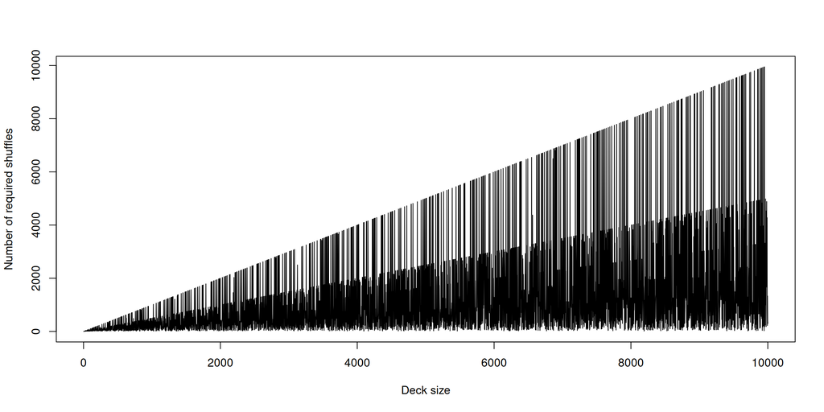

```r
## The deck sizes
deck_sizes <- as.list(seq(from = 2, to = 10000, by = 2))

## Apply all the deck shuffle sizes
shuffle_numbers <- lapply(deck_sizes, n.shuffles)

## Display the results
plot(deck_sizes, shuffle_numbers, type = "l",
     xlab = "Deck size", ylab = "Number of required shuffles")
```

**[Click to expand] Going level 2:**

This is fucking slow! How about optimising it? Maybe doing some `C` implementation?